# Apache Hive

### Student ID: [Monier Ashraf Monier Lawande]

### Subtasks Done: [221002188]

## Lab Goals:

1. Get overview about Hive.
2. Learn how to use Hive to create tables and perform queries against them.

# Introduction:

In this session we are going to work with Apache Hive. [Apache Hive](https://hive.apache.org/) is an open source software which facilitates reading, writing, and managing large datasets in distributed storage (HDFS/Hbase) using SQL-like queries.

- Hive uses HiveQL.
- it generates MapReduce jobs that run on Hadoop cluster.

# Hive Basic operations:

Here are some operations that Hive can performs:

- Create database
  - `CREATE DATABASE d;`.
  - `CREATE DATABASE IF NOT EXISTS d;`
- Drop database
  - `DROP DATABASE d;`
- Create table

  - ```
    CREATE TABLE tablename (colname DATATYPE, ...)
    ROW FORMAT DELIMITED
    FIELDS TERMINATED BY char
    LOCATION 'user/cloudera/a';
    ```

- Querying table
  - sql queries e.g. `SELECT a FROM B`
- Loading data
  - `hdfs dfs -mv /a/b.txt /user/hive/warehouse/b/`
  - `INSERT INTO TABLE a SELECT * FROM b;`

## Task 1: Create and populate a table:

In this task we are practicing table creation in hive. We are going to create table "webpage " and insert data into it.

- Before creating table you have to create a database
- We will be using the folder `webpage.zip`.

```python
!sudo hdfs dfs -mkdir HiveLab/
```

```python
from IPython.display import Image
```

```python
!unzip webpage.zip
```

```
Archive:  webpage.zip
   creating: webpage/
  inflating: webpage/part-m-00001
   creating: __MACOSX/
   creating: __MACOSX/webpage/
  inflating: __MACOSX/webpage/._part-m-00001
  inflating: webpage/part-m-00000
  inflating: __MACOSX/webpage/._part-m-00000
  inflating: webpage/.DS_Store
  inflating: __MACOSX/webpage/._.DS_Store
```

```python
!sudo hdfs dfs -put webpage  HiveLab/
```

```
put: `HiveLab/webpage/part-m-00000': File exists
put: `HiveLab/webpage/part-m-00001': File exists
put: `HiveLab/webpage/.ipynb_checkpoints/part-m-00000-checkpoint': File exists
put: `HiveLab/webpage/.ipynb_checkpoints/part-m-00001-checkpoint': File exists
put: `HiveLab/webpage/.DS_Store': File exists
```

### Use -ls to list files

```python
!sudo hdfs dfs -ls HiveLab/webpage
```

[output not shown]

- Now we will use the Hive shell to create `webpage` table in the terminal
  - write `sudo hive` to open the shell then write the following statement:
    - create database db1

    - ```
      CREATE TABLE webpage(page_id SMALLINT,name STRING,assoc_files STRING)
      ROW FORMAT DELIMITED
      FIELDS TERMINATED BY '\t'
      LOCATION '/user/hadoop/HiveLab/webpage';
      ```

- In the hue Refresh to see the table you just created.

### Use the command to show all tables in the database from the terminal and put screenshot here

```python
# Screenshot here
CREATE TABLE webpage(page_id SMALLINT,name STRING,assoc_files STRING) ROW FORMAT DELIMITED FIELDS TERMINATED BY '\t'  LOCATION '/user/hadoop/HiveLab/webpage';
```

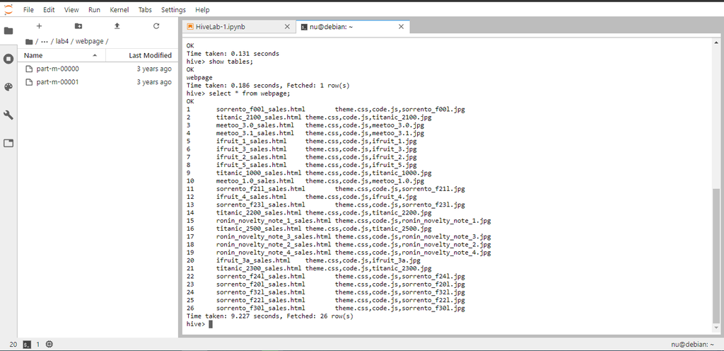

```python
Image(filename="/home/bitnami/Big_Data_Labs/lab4/Imges/1.png")
```

## Task 2: Perform queries against the created table:

### List all columns from the webpage table ordered by the name column

```python
# put a screenshot from the terminal output
SELECT * FROM webpage ORDER BY name ;
```

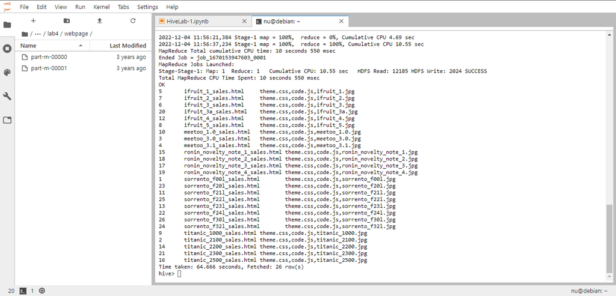

```python
Image(filename="/home/bitnami/Big_Data_Labs/lab4/Imges/2_1.png")
```

### Get all webpages which their names start by titanic

```python
# put a screenshot from the terminal output
SELECT * FROM webpage where name like "titanic%" ;
```

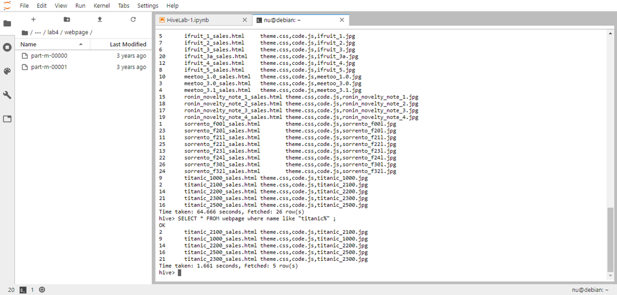

```python
Image(filename="/home/bitnami/Big_Data_Labs/lab4/Imges/2_2.png")
```

### Drop the table webpage

```python
# put a screenshot from the terminal output
DROP TABLE webpage;
```

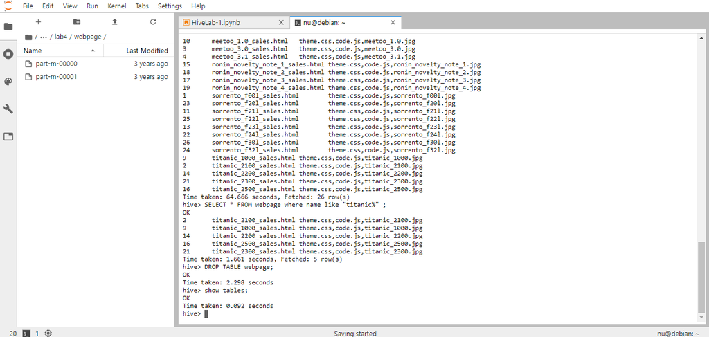

```python
Image(filename="/home/bitnami/Big_Data_Labs/lab4/Imges/2_3.png")
```

## Task 3: Data partitioning:

- We will be using the files `from part-m-00000 and part-m-00006 from accounts.zip` attached with this assignment.
- Put those files into the `hdfs` directory `/user/hadoop/HiveLab/accounts`
- Those files contain customer accounts information of a telecommunication company.

### Extract the accounts.zip files

```python
# your code here
!unzip accounts.zip
```

```
Archive:  accounts.zip
   creating: accounts/
  inflating: accounts/part-m-00006
  inflating: accounts/part-m-00005
  inflating: accounts/part-m-00004
  inflating: accounts/part-m-00003
  inflating: accounts/part-m-00002
  inflating: accounts/part-m-00001
  inflating: accounts/part-m-00000
```

### Make directory accounts inside HiveLab

```python
# your code here
!sudo hdfs dfs -mkdir HiveLab/accounts
```

### Put the extracted files into the hdfs directory /user/hadoop/HiveLab/accounts

```python
# your code here
!sudo hdfs dfs -put accounts/part-m-00000  /user/hadoop/HiveLab/accounts
```

```python
!sudo hdfs dfs -put accounts/part-m-00006  /user/hadoop/HiveLab/accounts
```

### Check

```python
#check
!sudo hdfs dfs -ls  /user/hadoop/HiveLab/accounts/
```

```
Found 2 items
-rw-r--r--   1 hadoop hadoop    4706617 2022-12-04 12:18 /user/hadoop/HiveLab/accounts/part-m-00000
-rw-r--r--   1 hadoop hadoop        131 2022-12-04 12:18 /user/hadoop/HiveLab/accounts/part-m-00006
```

### Now we moved the data it's time to create the table

### - The accounts table schema is as follows:

```
(
cust_id INT,
creationdate STRING,
expirationDate STRING,
fname STRING,
lname STRING,
address STRING,
city STRING,
state STRING,
zipcode STRING
)
```

```python
create table accounts (
cust_id INT,
creationdate STRING,
expirationDate STRING,
fname STRING,
lname STRING,
address STRING,
city STRING,
state STRING,
zipcode STRING
)
ROW FORMAT DELIMITED
FIELDS TERMINATED BY ','
LOCATION '/user/hadoop/HiveLab/accounts';
```

### - Create table accounts

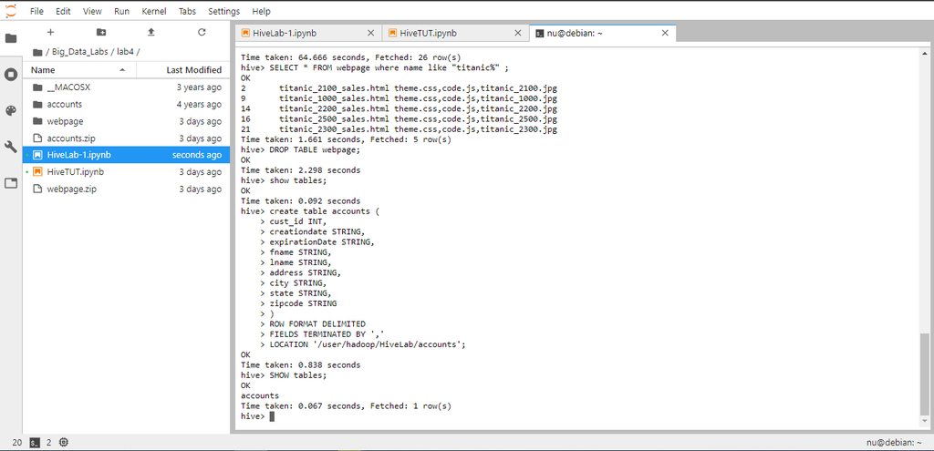

```python
## Screenshot of terminal show tables output here
Image(filename="/home/bitnami/Big_Data_Labs/lab4/Imges/3_1.png")
```

### - To create partitioned table accounts_by_State

- From `Hive Shell` run the following commands that will enable dynamic partitioning:

  ```
  SET  hive.exec.dynamic.partition = true;
  SET  hive.exec.dynamic.partition.mode = nonstrict;
  SET hive.exec.max.dynamic.partitions.pernode=400;
  ```

- ```
  CREATE Table accounts_by_State(
  cust_id INT,
  fname STRING,
  lname STRING,
  address STRING,
  city STRING,
  zipcode STRING
  )
  PARTITIONED BY (state STRING);
  ```

- Load data into `accounts_by_State`

  ```
  INSERT OVERWRITE TABLE accounts_by_State
  PARTITION(state)
  SELECT cust_id, fname, lname,address, city, zipcode, state
  FROM accounts;
  ```

```python
CREATE Table accounts_by_State(
cust_id INT,
fname STRING,
lname STRING,
address STRING,
city STRING,
zipcode STRING
)
PARTITIONED BY (state STRING);
```

### Perform queries on `accounts` and `accounts_by_State` tables

- Get the first name and the last name of all customers from "NV" state

```python
#put your queries and observations here.
select fname ,lname from accounts where state="NV";
```

```python
select fname ,lname from accounts_by_State where state="NV";
```

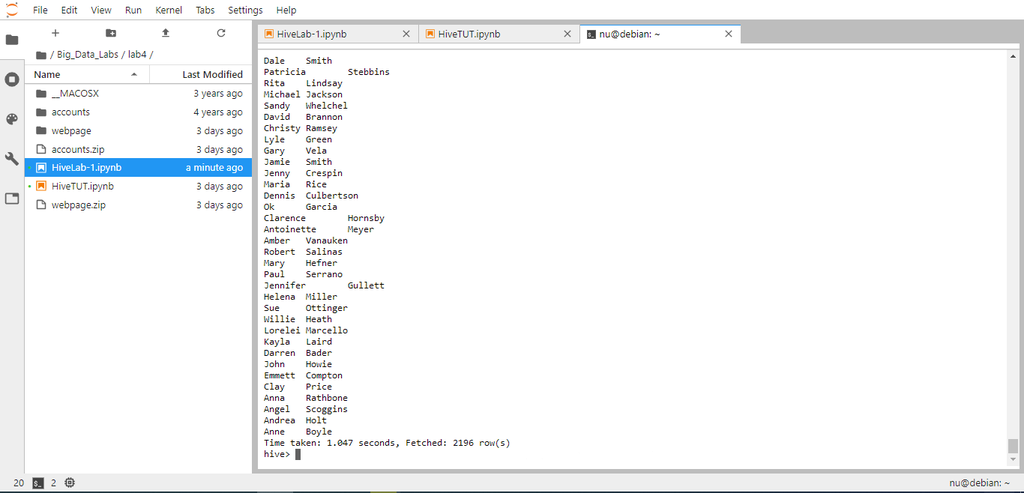

```python
Image(filename="/home/bitnami/Big_Data_Labs/lab4/Imges/3_2.png")
```

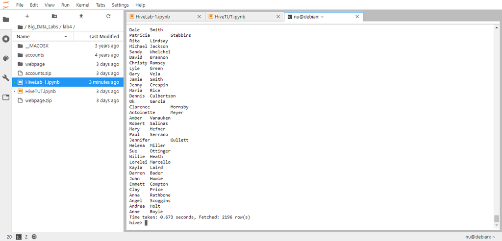

```python
Image(filename="/home/bitnami/Big_Data_Labs/lab4/Imges/3_3.png")
```

### Now we need to do further partitioning by state and city.

- Create partitioned table accounts_by_State_city:

  ```
  CREATE Table accounts_by_State_City(
  cust_id INT,
  fname STRING,
  lname STRING,
  address STRING,
  zipcode STRING
  )
  PARTITIONED BY (state STRING, city STRING)
  ```

- Insert data into it:

```
INSERT OVERWRITE TABLE accounts_by_State_City
PARTITION(state,city)
SELECT cust_id, fname, lname,address, zipcode, state, city
FROM accounts;
```

- Retrieve the names of the customers in the `CA,Oakland`
  - Apply such query against the three tables `accounts`, `accounts_by_State` and `accounts_by_State_City`

```python
##put your queries and observations here.
```

```python
select fname ,lname from accounts where state="CA" and city="Oakland";
```

```python
select fname ,lname from accounts_by_State where state="CA" and city="Oakland";
```

```python
select fname ,lname from accounts_by_State_City where state="CA" and city="Oakland";
```

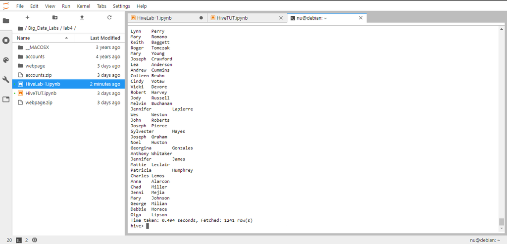

```python
Image(filename="/home/bitnami/Big_Data_Labs/lab4/Imges/3_4.png")
```

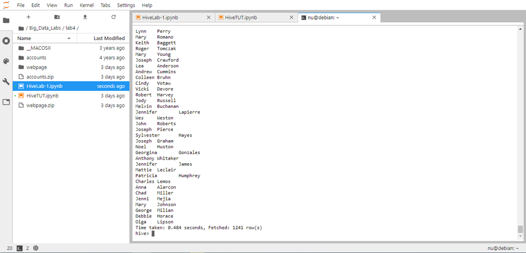

```python
Image(filename="/home/bitnami/Big_Data_Labs/lab4/Imges/3_5.png")
```

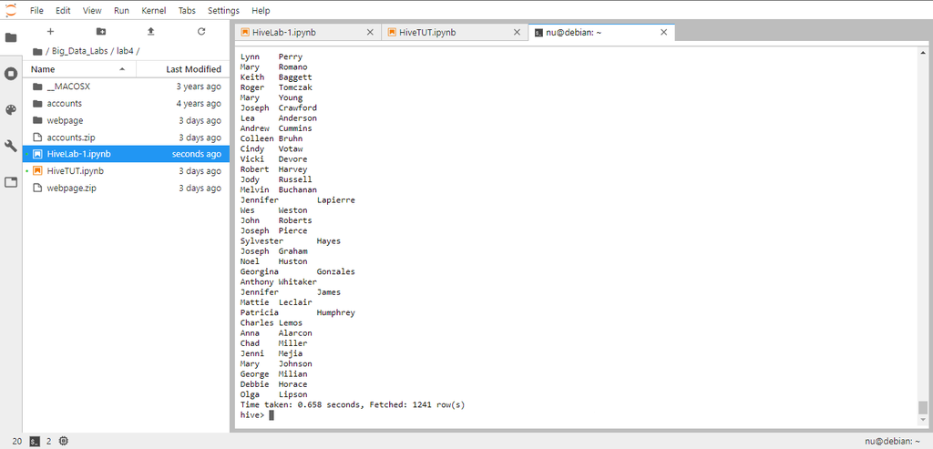

```python
Image(filename="/home/bitnami/Big_Data_Labs/lab4/Imges/3_6.png")
```

## Task 4: Data Bucketing

We will now need to practice bucketing of the data.

## Run those commands in terminal

set hive.exec.mode.local.auto.input.files.max=10  
SET hive.enforce.bucketing = true

```python
#put your queries and screenshots here
```

```python
CREATE Table accounts_in_buckets(
cust_id INT,
fname STRING,
lname STRING,
address STRING,
city STRING,
state STRING,
zipcode STRING
)
CLUSTERED BY (state)  INTO 2 BUCKETS;
```

```python
INSERT OVERWRITE TABLE accounts_in_buckets
SELECT cust_id, fname, lname,address, city, state, zipcode
FROM accounts;
```

[figure not shown]

```python
Image(filename="/home/bitnami/Big_Data_Labs/lab4/Imges/4.png")
```

## Task 5: Create a table `accountsPartStateBuckCity` partitioned by state and bucketed by city into 2 buckets

- Insert data into the table from accounts table
- put screenshot of hue

```python
CREATE Table accounts_PartState_BuckCity(
cust_id INT,
fname STRING,
lname STRING,
address STRING,
city STRING,
zipcode STRING

)
PARTITIONED BY (state STRING)
CLUSTERED BY (city)  INTO 2 BUCKETS;
```

```python
INSERT OVERWRITE TABLE accounts_PartState_BuckCity
PARTITION(state)
SELECT cust_id, fname, lname,address, city, zipcode, state
FROM accounts;
```

[figure not shown]

```python
Image(filename="/home/bitnami/Big_Data_Labs/lab4/Imges/5.png")
```

## Task 6: Change Storage Formats (No Grade)

We will use Hive to transform data formats from textual into other binary formats. We can transform the original `accounts` table into AVRO once and into Parquet another time.

- create table `accounts_avro` and instruct Hive to store it as AVRO
- Similarly, create table `accounts_parquet`
- Load the data from the original table `accounts` into the target tables via *insert from select* statements
- Finally, select customer names who lives in CA state from both tables to make sure that everything works fine.

```python
CREATE TABLE accounts_avro
STORED AS Avro
TBLPROPERTIES (
'avro.schema.literal'='{
  "type" : "record",
  "name" : "Accounts",
  "doc" : "Schema for the accounts_avro table",
  "fields" : [ {
    "name" : "cust_id",
    "type" : [ "int", "null" ]
  }, {
    "name" : "fname",
    "type" : [ "string", "null" ]
  }, {
    "name" : "lname",
    "type" : [ "string", "null" ]
  }, {
    "name" : "address",
    "type" : [ "string", "null" ]
  }, {
    "name" : "city",
    "type" : [ "string", "null" ]
  }, {
    "name" : "zipcode",
    "type" : [ "string", "null" ]
  }, {
    "name" : "state",
    "type" : [ "string", "null" ]
  } ]
}'

);
```

```python
INSERT OVERWRITE TABLE accounts_avro
SELECT cust_id, fname, lname,address, city, zipcode, state
FROM accounts;
```

[figure not shown]

```python
Image(filename="/home/bitnami/Big_Data_Labs/lab4/Imges/6_1.png")
```

Using the following schema for Avro

```
('avro.schema.literal'='{
  "type" : "record",
  "name" : "Accounts",
  "doc" : "Schema for the accounts_avro table",
  "fields" : [ {
    "name" : "cust_id",
    "type" : [ "int", "null" ]
  }, {
    "name" : "fname",
    "type" : [ "string", "null" ]
  }, {
    "name" : "lname",
    "type" : [ "string", "null" ]
  }, {
    "name" : "address",
    "type" : [ "string", "null" ]
  }, {
    "name" : "city",
    "type" : [ "string", "null" ]
  }, {
    "name" : "zipcode",
    "type" : [ "string", "null" ]
  }, {
    "name" : "state",
    "type" : [ "string", "null" ]
  } ]
}')
```

```python
CREATE Table accounts_parquet(
cust_id INT,
fname STRING,
lname STRING,
address STRING,
city STRING,
zipcode STRING,
state STRING

)
STORED AS Parquet;
```

```python
INSERT OVERWRITE TABLE accounts_parquet
SELECT cust_id, fname, lname,address, city, zipcode ,state
FROM accounts;
```

[figure not shown]

```python
Image(filename="/home/bitnami/Big_Data_Labs/lab4/Imges/6_2.png")
```

[figure not shown]

```python
Image(filename="/home/bitnami/Big_Data_Labs/lab4/Imges/6_3.png")
```

```python
select fname ,lname from accounts where state="CA";
```

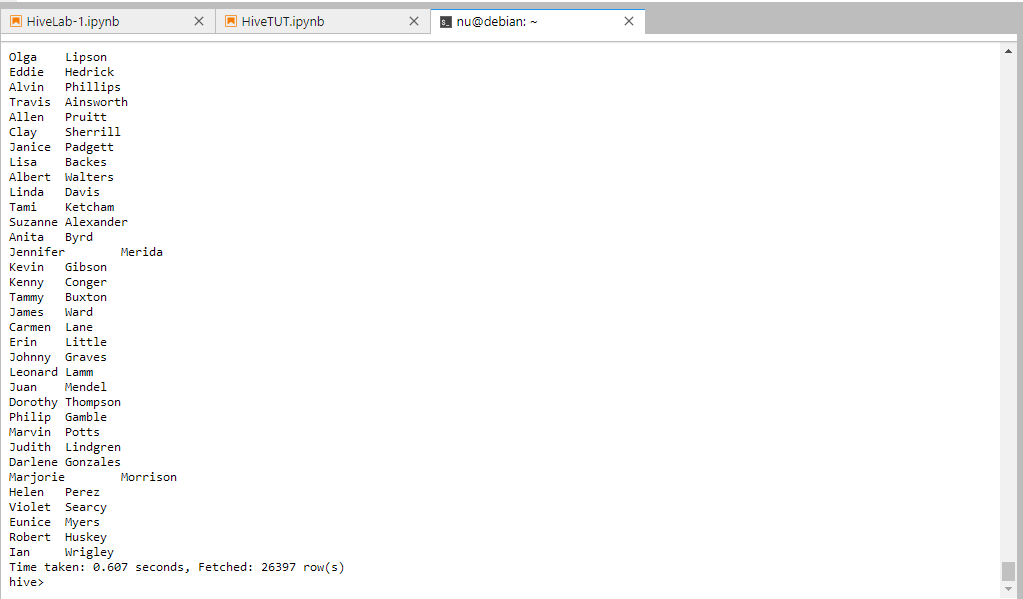

```python
Image(filename="/home/bitnami/Big_Data_Labs/lab4/Imges/6_6.png")
```

```python
select fname ,lname from accounts_avro where state="CA";
```

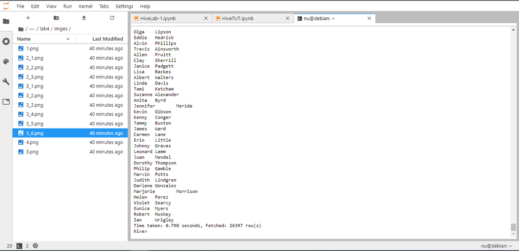

```python
Image(filename="/home/bitnami/Big_Data_Labs/lab4/Imges/6_5.png")
```

```python
select fname ,lname from accounts_parquet where state="CA";
```

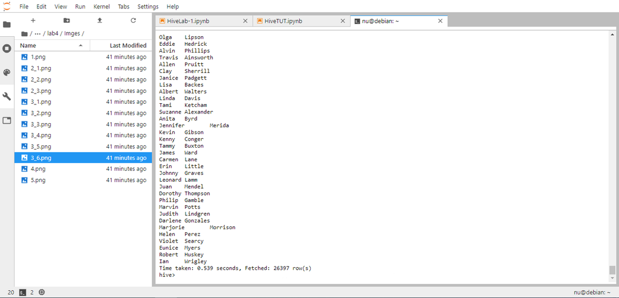

```python
Image(filename="/home/bitnami/Big_Data_Labs/lab4/Imges/6_4.png")
```